# Catastrophic Impacts of Climate Change

Green Team: Christine Hau, Wilson Ta, Phuong Lai,Aarav Dewangan

2/17/2022

- **Affiliation**- INFO-201: Technical Foundations of Informatics - The Information School - University of Washington.

## Abstract:-

This project focuses on the effects and impact of climate change, such as natural disasters. In order to address this, we will comb through existing data to examine the occurrence and frequency of natural disasters. We are concerned with this because climate change is a growing concern with catastrophic impacts such as environmental destruction, displacement, and more. Accordingly, we hope to demonstrate the urgency of climate change and the need for an intervention.

## Keywords:-

**Climate change**, **Environment**, **Natural Disaster**

## Introduction:

*Climate change* is becoming a topic of grave concern for all people. Thus our **group** has chosen this project to highlight some of the critical *reasons* for climate change. With this project, we hope to demonstrate the urgency of climate change and the need for an intervention. This project focuses on the effects and impact of climate change, such as natural disasters. To address this, we will comb through existing data to examine the occurrence and frequency of natural disasters and find the reasons.

## Values and Stakeholders:

Health awareness, responsibility, consideration are the human values that stem from the problem of climate change since dealing with this issue is protecting the future world for our younger generations. Confronting this concern will help us preserve the Earth for the future.

The direct stakeholders of climate change include the farmers and industrial manufacturers. For instance, the gasoline emissions from our vehicles contribute to 1.6 billion tons of greenhouse gasses which further exacerbate the impact of climate change (United States Environmental Protection Agency, 2022). Additionally, the production of hot-commodities such as processed foods, meat and poultry and greenhouse gasses to produce seasonal foods year-round attends to the demands of human lifestyle. Despite the direct impacts of human lifestyle, other aspects of the earth are impacted by climate change. Indirect stakeholders include us, the normal customers when the decrease in food or fuel supply will majorly affect people’s daily lives.

## Design Situation

Since the 1880s, the earth’s temperature has risen at a rate of at least 0.18 degrees Celsius per decade (Lindsey et al., 2021). With the earth’s climate temperature rising significantly, there have been major impacts to all aspects of life. Climate change has been a trending topic of discussion and in the recent decades, there has been increased awareness and effort to prevent further damage to the earth. From the ban on plastic bags and implementation of compost wastebins to the advent of electric cars and solar energy, technology has advanced to combat the negative effects of climate change.

Health awareness, responsibility, consideration are the human values that stem from the problem of climate change since dealing with this issue is protecting the future world for our younger generations. Confronting this concern will help us preserve the Earth for the future.

The direct stakeholders of climate change include the farmers and industrial manufacturers. For instance, the gasoline emissions from our vehicles contribute to 1.6 billion tons of greenhouse gasses which further exacerbate the impact of climate change (United States Environmental Protection Agency, 2022). Additionally, the production of hot-commodities such as processed foods, meat and poultry and greenhouse gasses to produce seasonal foods year-round attends to the demands of human lifestyle. Despite the direct impacts of human lifestyle, other aspects of the earth are impacted by climate change. Indirect stakeholders include us, the normal customers when the decrease in food or fuel supply will majorly affect people’s daily lives.

Although climate change has an overwhelming amount of negative effects, some benefits have arisen from it. If tackled with data and technology, we can easily find the gap in our system that leads to climate change in the first place. The usage of technology will enable us to analyze and give effective solutions to the issue. Using technology and data will be more effective in raising the public awareness about the environment, which leads to numerous benefits. For instance, with an increase in climate change awareness, there has been a more competitive job market especially for technology-related careers. This competition in turn will promote more innovation and technological advances. Additionally in the agriculture world, the usage of data will help farmers make decisions based on the climate data. For instance, there has been greater success with crop yields in the northern latitude regions for crops like wheat, barley, and oats that grow better in warmer climates (Kane et al., 1992). However, over-usage or mishandling of data might lead to public confusion due to wrong interpretation of data. Consequently, inappropriate decisions will be made which might cause further damage to the environment.

## Data Set:-

- [carbon dioxide in last 80 years](https://www.kaggle.com/ucsandiego/carbon-dioxide)
  - This dataset will answer the question about the cause of climate change by analyzing the change of carbon dioxide level in the atmosphere over the time and how it is related to the temperature of the Earth.
  - This dataset has 7 columns and 720 rows.
  - The carbon dioxide data was collected and published by the University of California’s Scripps Institution of Oceanography.

Data provided in this section is collected in an area called the “keeling curve” also known as the world’s largest unbroken record of atmospheric carbon dioxide conditions.

- [climate temperature in last 2 centuries](https://www.kaggle.com/berkeleyearth/climate-change-earth-surface-temperature-data)
  - This dataset can be used to answer how severe the climate change is and whether or not climate change is affecting our planet. It also demonstrates the change of surface temperature over time, which helps us answer the question of how likely climate change will affect our lives (food supply,melting ice, etc…).
  - This dataset has 5 data files, with 4-9 columns and 3176 to roughly 8.6 millions rows.
  - This dataset is created by The Berkeley Earth Surface Temperature Study by combining 1.6 billion temperature reports from 16 pre-existing archives.
- [natural disasters in last 2 centuries](https://www.kaggle.com/brsdincer/all-natural-disasters-19002021-eosdis)
  - This dataset can be used to answer the impacts of climate change and how the climate change affected the frequency of natural disasters. By analyzing the pattern of natural events in the last 2 decades and compare it to the rate of climate change in the last 20 years, we can solve the relationship between climate change and catastrophic natural events.
  - This dataset has 2 data files, each has 14k-16k rows and 45 columns of data.
  - The dataset is composed and published by EOSDIS SYSTEM.
- [Export of good and services](https://data.worldbank.org/indicator/NE.EXP.GNFS.ZS)
  - This dataset provides the means to calculate the manufacturing power of the countries since manufacturing power correlates with export and import goods. This is important in answering the question of how economic growth associates with climate change. Combining this data with the change of surface temperature in countries will help us solve the relationship between factories and the atmosphere.
  - The data is provided by the World Bank.

## Research Questions:

In our project, we hope to deal with following questions:

- How do increasing global surface temperature impact the possibility of other natural disasters occurring?
- What region has the highest global surface temperature?
- Where is climate change most impacting our oceans, in what ways does this hurt the environment around this area? What are the exact ozone layers?
- What animals are we seeing have the lowest survival rates due to climate change? What species is it?
- In what areas of the world does climate change impact deforestation?

The importance of these research questions are motivated to see the natural occurrences that are impacted globally by climate change. Climate change has been hurting our climate at an alarming rate for many years. The purpose of these research questions is to see where exactly certain regions are having a direct impact. If we can identify these key regions we can see other key components like factors that may be altering the climate in order to get a bigger picture of what we can expect in the future. Ultimately, for any scientist or someone that wants to help protect our planet by compiling these data points in the structure of research questions we can take preventative measures to decrease any future impact. The topic specifically relating to natural disasters within the topic of climate change is crucial to help understand the levels of increasing global surface temperatures that cause additional disasters if we want to have a future planet at all.

## Summary Statistics of 5 Variables:-

```
## $max_land__avg_temperature
## [1] 21.32
##
## $min_land__avg_temperature
## [1] 7.229
##
## $max_land_ocean_temperature
## [1] 17.611
##
## $min_land_ocean_temperature
## [1] 13.298
##
## $mean_affected_since_1958
## [1] 880213.9
##
## $max_co2_level
## [1] 407.65
##
## $min_co2_level
## [1] 313.21
##
## $mean_death_since_1958
## [1] 696.9764
```

The 5 variables that we have chosen to dissect the datasets are the following:-

- Carbon dioxide levels -

The maimum carbon dioxide level was 407.65 ppm in 2016 and the minimum carbon dioxide level was 313.21 ppm in 1958.

- Average Number of deaths -

- Average Number of Affected people

## Tables:-

```
## # A tibble: 62 × 5
## # Groups:   Year [60]
##     Year Carbon.Dioxide..ppm. Seasonally.Adjusted.… AverageLandTemp LandOceanAvg
##    <dbl>                <dbl>                 <dbl>           <dbl>        <dbl>
##  1  1958                 318.                  316.            8.77         15.4
##  2  1959                 318.                  317.            8.73         15.3
##  3  1960                 320.                  318.            8.58         15.3
##  4  1961                 321.                  318.            8.80         15.4
##  5  1962                 321.                  319.            8.75         15.3
##  6  1963                 322.                  319.            8.86         15.4
##  7  1964                 322.                  320.            8.41         15.1
##  8  1965                 322.                  321.            8.53         15.2
##  9  1966                 324.                  322.            8.60         15.3
## 10  1967                 325                   323.            8.70         15.3
## # … with 52 more rows
```

The striking values are the ones found in the year 2017 for the level of Carbon dioxide and level of seasonally adjusted Carbon dioxide and in 2015 for land average temperature and land and ocean average temperature. These are significantly very large values when compared to the values at the starting year (1958). So these values are successful in demonstrating the harmful effects of climate change.

## Charts-

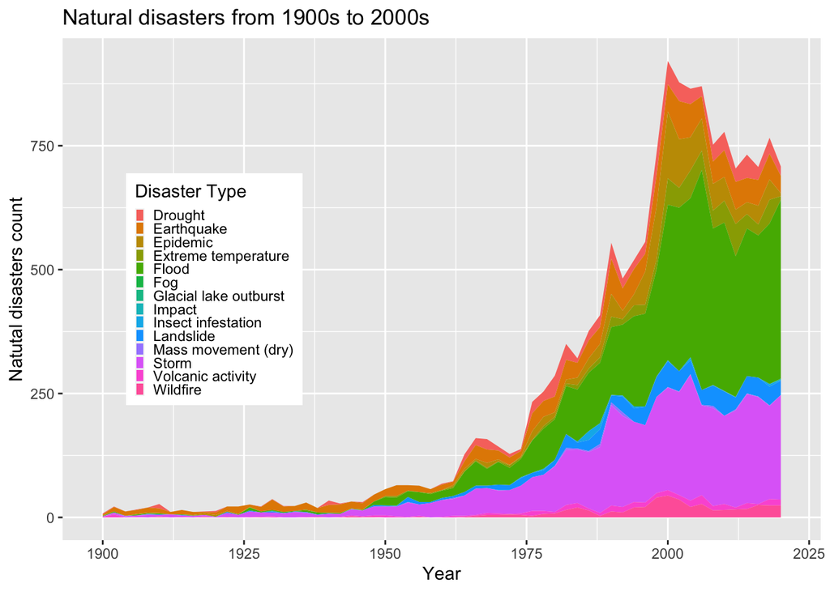

We have used stacked area chart to depict how natural disasters have been growing from 1900 to 2021. Specifically, the years have been drawn on the x-axis, and the y axis is the number of natural disasters. This graph gives us a clear indication that as the number of years passed by, natural disasters have increased. With years passing by, the climate has deteriorated, resulting in an increase in the number of natural disasters over the years. This shows a direct effect of climate change.

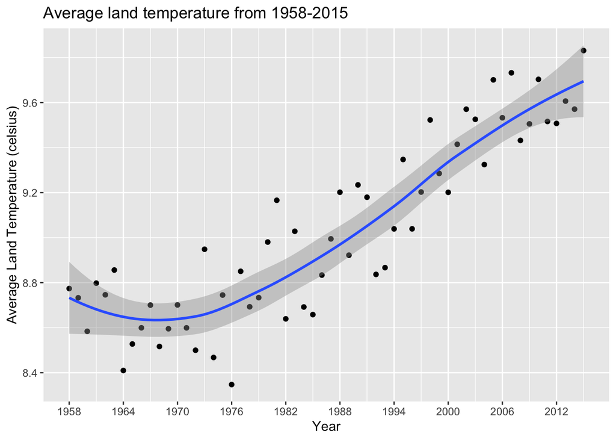

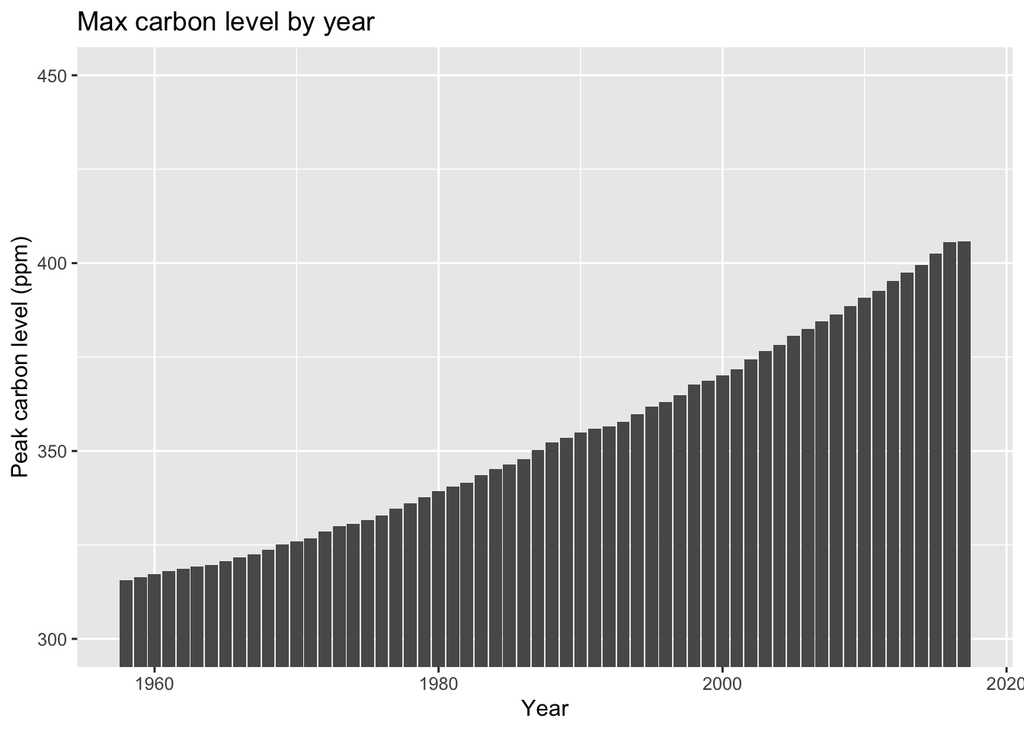

## Expected implications:

We hope to develop an innovative and captivating representation of climate change by analyzing data regarding natural disasters. We aim to help visualize the importance of addressing and intervening in climate change. This may have implications such as informing policymakers for possible legislation to address contributors to climate change. In addition, our data may support filmmakers and artists who seek to portray the growing urgency of climate change into accessible media for the general public. Furthermore, this analysis may prompt further research into climate change in academia, especially marginalized and vulnerable populations impacted by climate change and natural disasters. We hope by analyzing and developing this project, we could see both short term and long term solutions to address climate change and natural disasters. As well as support those most impacted by climate change.

## Limitations:

Natural disasters is a large umbrella term for many events such as earthquakes, tsunamis, typhoons, and more. Therefore, it may be difficult to accurately and efficiently capture all natural disaster events due to the large scope of natural disasters. In addition, existing data may not necessarily capture the disproportionate and inequitable effects of natural disasters and climate change in the Global South and low-income communities (Vidal, 2013). Nor will the data demonstrate the majority of environmental justice and land stewardship has been practiced by Indigenous peoples and BIPOC communities (Rights and Resources, 2020). For example, rising sea levels affecting Pacific Islander nations or the growing concern of climate refugees and migrants due to desertification (Podesta, 2021). It is also important to note that, as Data Feminism discusses, no data is neutral (D’Ignazio and Klein, 2020). In order to address the validity and perceived neutrality of our data. We must acknowledge that our data are limited in our attempt to convey the urgency to address climate change and natural disasters. Although there is statistical and empirical data, this does not necessitate fact.

## Acknowledgements:

Kaggle, Mauna Loa Observatory, Wang Q, Taylor JE (2016) Patterns and limitations of urban human mobility resilience under the influence of multiple types of natural disaster, Dryad digital repository and any scientist that helped us collect this data.

## References:

- [Lindsey, R., & Dahlman, L. A. (2021, August 12). Climate change: Global temperature. Climate Change: Global Temperature | NOAA Climate.gov. Retrieved February 4, 2022,](https://www.climate.gov/news-features/understanding-climate/climate-change-global-temperature#:~:text=According%20to%20NOAAs%202020%20Annual,more%20than%20twice%20that%20rate.)
- D’Ignazio C, Klein LF. Data Feminism. Cambridge, MA: The MIT Press; 2020.
- [Podesta J. The climate crisis, migration, and refugees. Brookings.](https://www.brookings.edu/research/the-climate-crisis-migration-and-refugees/.PublishedJuly1,2021.AccessedFebruary4,2022.)
- [Rights and Resources. Toward a global baseline of carbon storage in collective lands: An updated analysis of Indigenous Peoples’ and local communities’ contributions to climate change mitigation. Rights + Resources.](https://rightsandresources.org/global-baseline-carbon-storage-collective-lands/.PublishedMarch16,2020.AccessedFebruary4,2022.)
- [Vidal J. Climate change will hit poor countries hardest, study shows. The Guardian](https://www.theguardian.com/global-development/2013/sep/27/climate-change-poor-countries-ipcc.%20Published%20September%2027,%202013.%20Accessed%20February%204,%202022.)
- [Kane, S., Reilly, J., & Tobey, J. (1992). An empirical study of the economic effects of climate change on World Agriculture. Climatic Change, 21(1), 17–35.](https://doi.org/10.1007/bf00143251)